# Rapport de surveillance et performance des alertes MVE

Évaluation longitudinale de l'adéquation des notifications d'alertes par rapport aux seuils épidémiologiques et démographiques

[Accéder à l'application en ligne](https://cai-cousp.github.io/BVD-Alert-performance/)

**Auteur :** IOA-CAI © 2026 | **Date de publication :** 27 September 2026 | **Source des données :** DHIS2-Tracker (27-09-2026) | **Période couverte :** du 30/03/2026 au 27/09/2026 (26 semaines d'analyse)  
**Exécutions mobilisées :** seuils & nowcast 2026_09_27 | tendances 2026_09_27 | carte 2026_09_27  
**Plateforme interactive (GitHub Pages) :** https://cai-cousp.github.io/BVD-Alert-performance/

# 1 Objectif du rapport

Ce rapport a pour objectif d’évaluer de manière quantitative la sensibilité, la réactivité et l’adéquation opérationnelle du système de notification des alertes de cas (personnes vivantes) et de décès communautaires dans les zones de santé affectées par la Maladie à Virus Ebola (MVE). En confrontant les volumes réels d’alertes validées à des seuils d’attente épidémiologiques et démographiques modélisés, cette analyse vise à :

1. **Mesurer la sensibilité de la surveillance** : Déterminer si le nombre d’alertes captées est suffisant pour interrompre efficacement les chaînes de transmission actives.
2. **Identifier précocement les zones sous-notificatrices** : Détecter les zones de santé en situation de silence épidémiologique ou de déficit critique d’alertes par rapport à leur charge de cas estimée.
3. **Quantifier la taille réelle de l’épidémie** : Corriger les séries temporelles pour les délais de rapportage (nowcasting) et la sous-détection afin de fournir une estimation robuste du fardeau global et d’ajuster les ressources de riposte.

# 2 Questions adressées par le rapport

Ce rapport répond aux questions opérationnelles et stratégiques suivantes :

- **Adéquation du volume d’alertes** : Les notifications d’alertes de cas vivants et de décès communautaires atteignent-elles les niveaux minimaux requis pour garantir le contrôle épidémique au niveau global et dans chaque zone de santé ?
- **Sensibilité de détection par type d’alerte** : Observe-t-on un déséquilibre entre la surveillance des cas vivants et la surveillance des décès dans la communauté ?
- **Fardeau caché et dynamique de transmission** : Quelle est la taille réelle estimée de l’épidémie après ajustement pour la sous-détection et les délais de notification de laboratoire ?
- **Priorisation géographique** : Quelles sont les zones de santé les plus critiques nécessitant un renforcement immédiat des équipes d’investigation, de recherche active et d’engagement communautaire ?

# 3 Méthode

L’évaluation de la performance repose sur la modélisation hebdomadaire de seuils d’alertes attendues combinant trois approches complémentaires : l’**Approche A (Mortalité de base)** qui établit le plancher des décès attendus à partir du taux brut de mortalité national (8,3 pour 1 000 personnes-années) appliqué à la population de chaque zone ; l’**Approche B (Référence historique)** qui utilise les taux d’alertes de surveillance optimale issus de l’épidémie historique de Beni (EVD10) ; et l’**Approche C (Dynamique actuelle dérivée des cas)** qui intègre le nowcasting bayésien par modèle lognormal pour corriger la troncature des délais de notification récents, le taux de reproduction effectif $R_t$ (EpiEstim), les taux d’attaque secondaire (SAR), et des modèles log-linéaires de Poisson à décalage estimant les multiplicateurs d’alertes $\beta_c$ (cas vivants) et $\beta_d$ (décès) ajustés pour le taux de détection combiné (rétro-calcul du taux de létalité et liens épidémiologiques). La synthèse des approches produit des bornes de seuils consensuelles permettant de calculer l’**Indice d’Adéquation des Alertes ($AAI$)** et les ratios de performance par semaine d’analyse glissante non chevauchante de 7 jours.

# 4 Performances

## 4.1 Niveau Global (Ensemble de la zone affectée)

### 4.1.1 Graphiques des tendances et de la performance globale

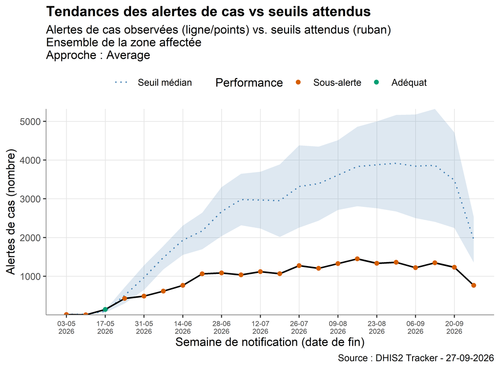

Figure 1: Tendances des alertes de cas vs. seuils attendus (Ensemble de la zone affectée)

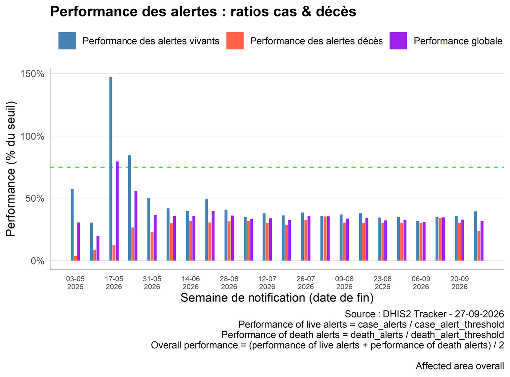

Figure 2: Performance globale des alertes : ratios cas & décès (Ensemble de la zone affectée)

### 4.1.2 Interprétation du graphique de performance

- **Barres bleues (Performance des alertes vivants)** : Rapport entre les alertes de cas vivants validées et le seuil attendu ($\text{Alertes cas} / \text{Seuil cas}$). Une valeur $\ge 100\%$ indique que la détection active des cas vivants atteint le niveau modélisé.
- **Barres rouges (Performance des alertes décès)** : Rapport entre les alertes de décès communautaires et le seuil de mortalité attendu ($\text{Alertes décès} / \text{Seuil décès}$). Une valeur $< 50\%$ traduit une faiblesse critique de la surveillance des décès dans la communauté.
- **Barres violettes (Performance globale — AAI)** : Moyenne arithmétique des performances cas et décès.
- **Ligne verte pointillée (Seuil de vigilance à 75 %)** : Objectif opérationnel minimal de complétude de surveillance.

### 4.1.3 Tableau des paramètres pour les 6 dernières semaines

Le tableau ci-dessous présente les indicateurs de surveillance et les paramètres épidémiologiques du modèle pour l’ensemble de la zone affectée au cours des 6 dernières semaines :

Table 1: Paramètres épidémiologiques et performance des alertes — Ensemble de la zone affectée (6 dernières semaines)

| Semaine de notification (début) | Alertes Cas | Alertes Décès | Seuil Cas | Seuil Décès | Perf. Cas | Perf. Décès | AAI | Cas obs. | Taux Détect. | Cas vrais est. |
| --- | --- | --- | --- | --- | --- | --- | --- | --- | --- | --- |
| 21/09/2026 | 764 | 383 | 1 942 | 1 612 | 39.3 % | 23.8 % | 0.32 | 52 | 33.9 % | 357 |
| 14/09/2026 | 1 232 | 603 | 3 480 | 2 011 | 35.4 % | 30 % | 0.33 | 262 | 64.4 % | 494 |
| 07/09/2026 | 1 348 | 684 | 3 863 | 2 008 | 34.9 % | 34.1 % | 0.34 | 413 | 45.2 % | 932 |
| 31/08/2026 | 1 222 | 595 | 3 840 | 1 986 | 31.8 % | 30 % | 0.31 | 450 | 32.5 % | 1 384 |
| 24/08/2026 | 1 360 | 580 | 3 918 | 1 938 | 34.7 % | 29.9 % | 0.32 | 450 | 50.8 % | 885 |
| 17/08/2026 | 1 333 | 576 | 3 878 | 1 929 | 34.4 % | 29.9 % | 0.32 | 446 | 47.1 % | 946 |

### 4.1.4 Synthèse des paramètres épidémiologiques globaux

Sous l’ensemble des semaines analysées depuis le début de la riposte, les indicateurs cumulés de la zone affectée s’établissent comme suit :

7 146

Cas confirmés rapportés

36.8 %

Taux de détection global moyen

Moyenne sur toutes les semaines

19 426

Taille estimée de l'épidémie

Somme des cas vrais estimés

> [!IMPORTANT] **Synthèse d’exhaustivité :** Sur l’ensemble de l’épidémie, pour 7 146 cas confirmés notifiés, le modèle estime à **19 426 cas vrais** la taille cumulée de l’épidémie (soit environ 2.7 cas réels pour chaque cas détecté). Le taux moyen de détection de **36.8 %** démontre la nécessité de maintenir un niveau élevé d’alertes validées pour endiguer les chaînes de transmission résiduelles.

## 4.2 Niveau Zones de santé (Les 6 zones les plus affectées)

### 4.2.1 Graphique facetté de la performance des 6 zones les plus affectées

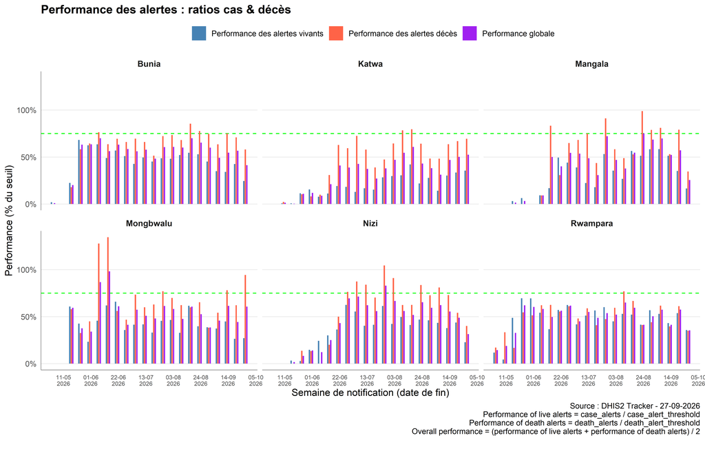

Figure 3: Performance longitudinale des alertes dans les 6 zones de santé les plus affectées

### 4.2.2 Paramètres des 6 zones les plus affectées pour la dernière semaine

Le tableau suivant détaille la situation épidémiologique et les paramètres de performance pour la dernière semaine (21/09/2026) :

Table 2: Paramètres des alertes et du modèle — 6 zones les plus affectées (Dernière semaine)

| Zone de santé | Alertes Cas | Alertes Décès | Seuil Cas | Seuil Décès | Perf. Cas | Perf. Décès | AAI | Cas obs. | Taux Détect. | Cas vrais est. |
| --- | --- | --- | --- | --- | --- | --- | --- | --- | --- | --- |
| Mangala (Ituri) | 17 | 9 | 103 | 26 | 16.5 % | 34.6 % | 0.26 | 2 | 54.6 % | 7 |
| Nizi (Ituri) | 37 | 28 | 163 | 70 | 22.7 % | 40 % | 0.31 | 3 | 37.9 % | 16 |
| Rwampara (Ituri) | 88 | 15 | 246 | 43 | 35.8 % | 34.9 % | 0.35 | 8 | 40.4 % | 54 |
| Bunia (Ituri) | 68 | 77 | 277 | 132 | 24.5 % | 58.1 % | 0.41 | 11 | 53.8 % | 39 |
| Katwa (Nord Kivu) | 67 | 51 | 189 | 74 | 35.5 % | 69.4 % | 0.52 | 2 | 55.6 % | 7 |
| Mongbwalu (Ituri) | 25 | 25 | 93 | 26 | 27 % | 94.3 % | 0.61 | 1 | 43.7 % | 5 |

## 4.3 Cartographie de la performance de notification par zone de santé

La carte suivante spatialise la classification de la performance de notification des zones de santé calculée sur la moyenne de l’indice d’adéquation des alertes ($AAI$) des trois dernières semaines d’analyse (07/09/2026 au 27/09/2026).

Cette lecture cartographique permet de situer géographiquement le niveau de vigilance et d’orienter les priorités opérationnelles :

- Sous-notification : $AAI < 0,75$ (Surveillance insuffisante, risque élevé d’extension silencieuse des chaînes de transmission).
- Notification adéquate : $0,75 \le AAI \le 2,00$ (Sensibilité et réactivité conformes aux attentes épidémiologiques).
- Surnotification : $AAI > 2,00$ (Volume d’alertes supérieur aux attentes, nécessitant un tri rigoureux pour préserver la réactivité).

Les zones grisées correspondent aux zones sans données dans le périmètre d’analyse ou hors périmètre. La légende n’affiche que les catégories effectivement observées sur le terrain.

57

Zones en sous-notification

AAI moyen < 0,75 (Priorité recherche active)

1

Zones adéquates

0,75 ≤ AAI moyen ≤ 2,00 (Volume attendu)

0

Zones en surnotification

AAI moyen > 2,00 (Tri et validation requis)

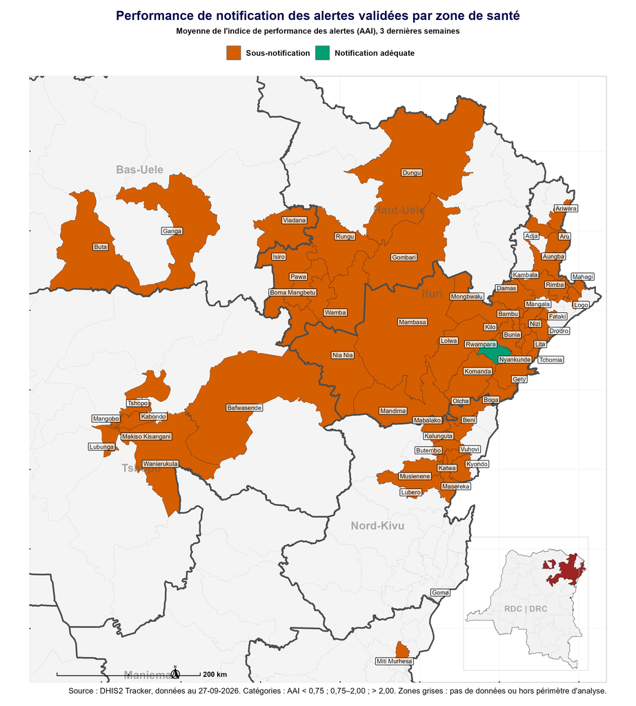

Figure 4: Performance de notification des alertes validées par zone de santé (moyenne AAI, 3 dernières semaines)

Cette lecture spatiale complète les analyses temporelles : elle identifie les zones en sous-notification critique où déployer en priorité la recherche active des cas et le réseau de notification communautaire (RECO).

Table 3: Détail de la performance de notification par zone de santé cartographiée (3 dernières semaines)

| Zone de santé | Province | AAI moyen | Statut | Délai moyen | Tendance |
| --- | --- | --- | --- | --- | --- |
| Buta | Bas-Uele | 0.14 | Sous-notification | 4.0 j | En hausse ↗ |
| Ganga | Bas-Uele | 0.01 | Sous-notification | 4.0 j | En hausse ↗ |
| Viadana | Bas-Uele | 0.02 | Sous-notification | 4.0 j | En hausse ↗ |
| Boma Mangbetu | Haut-Uele | 0.12 | Sous-notification | 4.7 j | En hausse ↗ |
| Dungu | Haut-Uele | 0.03 | Sous-notification | 4.0 j | En hausse ↗ |
| Gombari | Haut-Uele | 0.01 | Sous-notification | 4.0 j | En hausse ↗ |
| Isiro | Haut-Uele | 0.18 | Sous-notification | 4.3 j | En hausse ↗ |
| Pawa | Haut-Uele | 0.18 | Sous-notification | 1.8 j | En hausse ↗ |
| Rungu | Haut-Uele | 0.02 | Sous-notification | 4.0 j | En hausse ↗ |
| Wamba | Haut-Uele | 0.24 | Sous-notification | 2.7 j | En hausse ↗ |
| Adja | Ituri | 0.02 | Sous-notification | 4.0 j | En hausse ↗ |
| Ariwara | Ituri | 0.07 | Sous-notification | 4.0 j | En hausse ↗ |
| Aru | Ituri | 0.33 | Sous-notification | 4.0 j | En hausse ↗ |
| Aungba | Ituri | 0.03 | Sous-notification | 4.0 j | En hausse ↗ |
| Kambala | Ituri | 0.02 | Sous-notification | 4.0 j | En hausse ↗ |
| Logo | Ituri | 0.13 | Sous-notification | 4.0 j | En hausse ↗ |
| Mahagi | Ituri | 0.14 | Sous-notification | 4.0 j | En hausse ↗ |
| Rimba | Ituri | 0.12 | Sous-notification | 4.0 j | En hausse ↗ |
| Bambu | Ituri | 0.20 | Sous-notification | 3.7 j | En hausse ↗ |
| Boga | Ituri | 0.08 | Sous-notification | 4.0 j | En hausse ↗ |
| Bunia | Ituri | 0.51 | Sous-notification | 4.7 j | En hausse ↗ |
| Damas | Ituri | 0.15 | Sous-notification | 4.0 j | En hausse ↗ |
| Drodro | Ituri | 0.03 | Sous-notification | 4.0 j | En hausse ↗ |
| Fataki | Ituri | 0.31 | Sous-notification | 4.0 j | En hausse ↗ |
| Gety | Ituri | 0.13 | Sous-notification | 4.0 j | En hausse ↗ |
| Kilo | Ituri | 0.42 | Sous-notification | 4.0 j | En hausse ↗ |
| Komanda | Ituri | 0.43 | Sous-notification | 5.3 j | En hausse ↗ |
| Lita | Ituri | 0.39 | Sous-notification | 2.8 j | En hausse ↗ |
| Lolwa | Ituri | 0.37 | Sous-notification | 4.0 j | En hausse ↗ |
| Mambasa | Ituri | 0.71 | Sous-notification | 4.0 j | En hausse ↗ |
| Mandima | Ituri | 0.63 | Sous-notification | 5.0 j | En hausse ↗ |
| Mangala | Ituri | 0.45 | Sous-notification | 5.3 j | En hausse ↗ |
| Mongbwalu | Ituri | 0.55 | Sous-notification | 5.0 j | En hausse ↗ |
| Nia Nia | Ituri | 0.47 | Sous-notification | 3.7 j | En hausse ↗ |
| Nizi | Ituri | 0.45 | Sous-notification | 4.0 j | En hausse ↗ |
| Nyankunde | Ituri | 1.12 | Notification adéquate | 5.0 j | En hausse ↗ |
| Rwampara | Ituri | 0.45 | Sous-notification | 4.3 j | En hausse ↗ |
| Tchomia | Ituri | 0.39 | Sous-notification | 4.0 j | En hausse ↗ |
| Beni | Nord-Kivu | 0.32 | Sous-notification | 6.2 j | En hausse ↗ |
| Butembo | Nord-Kivu | 0.23 | Sous-notification | 3.0 j | En hausse ↗ |
| Kalunguta | Nord-Kivu | 0.00 | Sous-notification | - | Stable → |
| Katwa | Nord-Kivu | 0.50 | Sous-notification | 4.0 j | En hausse ↗ |
| Kyondo | Nord-Kivu | 0.64 | Sous-notification | 4.0 j | En hausse ↗ |
| Lubero | Nord-Kivu | 0.15 | Sous-notification | 4.7 j | En hausse ↗ |
| Mabalako | Nord-Kivu | 0.09 | Sous-notification | 6.7 j | En hausse ↗ |
| Masereka | Nord-Kivu | 0.00 | Sous-notification | - | Stable → |
| Musienene | Nord-Kivu | 0.08 | Sous-notification | 2.3 j | En hausse ↗ |
| Oicha | Nord-Kivu | 0.34 | Sous-notification | 3.3 j | En hausse ↗ |
| Vuhovi | Nord-Kivu | 0.08 | Sous-notification | 4.0 j | En hausse ↗ |
| Goma | Nord-Kivu | 0.00 | Sous-notification | - | Stable → |
| Miti Murhesa | Sud-Kivu | 0.00 | Sous-notification | - | Stable → |
| Bafwasende | Tshopo | 0.24 | Sous-notification | 3.0 j | En hausse ↗ |
| Kabondo | Tshopo | 0.08 | Sous-notification | 4.0 j | En hausse ↗ |
| Lubunga | Tshopo | 0.06 | Sous-notification | 4.0 j | En hausse ↗ |
| Makiso Kisangani | Tshopo | 0.06 | Sous-notification | 5.3 j | En hausse ↗ |
| Mangobo | Tshopo | 0.05 | Sous-notification | 4.0 j | En hausse ↗ |
| Tshopo | Tshopo | 0.04 | Sous-notification | 4.0 j | En hausse ↗ |
| Wanierukula | Tshopo | 0.01 | Sous-notification | 4.0 j | En hausse ↗ |

# 5 Conclusion et recommandations

## 5.1 Synthèse des alertes et impact sur la trajectoire de l’épidémie

> [!WARNING] **Alerte épidémiologique opérationnelle (OMS / Commission Surveillance) :** L’analyse consolidée des trois dernières semaines de surveillance (07/09/2026 au 27/09/2026) met en évidence un **décrochage critique de la sensibilité du système d’alerte**. Alors que la transmission communautaire demeure active dans plusieurs zones de santé, le volume global d’alertes s’est contracté de **44%**, faisant chuter l’Indice d’Adéquation des Alertes ($AAI$) global à **31.5 %** lors de la dernière semaine. **100 % des 6 zones de santé les plus affectées** se situent désormais en dessous du seuil opérationnel d’adéquation ($AAI < 75\%$). Cette défaillance de détection crée un angle mort majeur favorisant l’extension silencieuse des chaînes de transmission.

### 5.1.1 1. Évaluation générale de la performance du système d’alerte

Dans le dispositif de réponse à la Maladie à Virus Ebola (MVE), le système de notification et de validation des alertes constitue le premier rempart contre la propagation du virus. Pour garantir l’interruption des chaînes de transmission, il doit impérativement répondre à deux impératifs épidémiologiques fondamentaux : 1. **Capter précocement les cas vivants symptomatiques** dès le premier contact communautaire afin de réduire à moins de 24 heures le délai entre l’apparition des symptômes et l’isolement en Centre de Traitement Ebola (CTE) ; 2. **Intercepter et tester systématiquement 100 % des décès survenus dans la communauté** (par écouvillonnage buccal post-mortem) avant toute manipulation funéraire afin de prévenir les événements de super-propagation liés aux rites mortuaires traditionnels.

Cette sous-notification générale masque en outre un déséquilibre opérationnel périlleux entre les deux composantes de la surveillance : * **Surveillance des cas vivants (personnes symptomatiques)** : L’adéquation moyenne s’établit à **36.5 %** sur les 3 dernières semaines (3 344 alertes enregistrées). Ce niveau insuffisant témoignerait d’une recherche active des cas trop passive ?, souvent confinée aux structures de soins étatiques et moins orientée vers les structures privées informelles, les cabinets de tradipraticiens et les domiciles? * **Surveillance des décès communautaires** : L’adéquation moyenne n’atteint que **29.3 %** (1 670 alertes de décès validées), avec une dégradation spectaculaire à **23.8 %** lors de la dernière semaine. Ce déficit structurel démontre qu’une immense majorité des décès survenus hors milieu hospitalier échappe à l’alerte, au prélèvement sécurisé et aux protocoles d’enterrements dignes et sécurisé (EDS).

### 5.1.2 2. Dynamique de la surveillance sur les 3 dernières semaines (du 07/09/2026 au 27/09/2026)

#### 5.1.2.1 A. Évolution au niveau Global (« Ensemble de la zone affectée »)

L’évaluation séquentielle sur les trois dernières semaines met en lumière une trajectoire d’érosion continue et préoccupante :

- **Semaine 1 (07/09)** : 2 032 alertes validées (1 348 cas, 684 décès) pour un $AAI$ de **34.5 %** (adéquation cas : 34.9 %, décès : 34.1 %) ;
- **Semaine 2 (14/09)** : 1 835 alertes validées (1 232 cas, 603 décès) pour un $AAI$ de **32.7 %** (adéquation cas : 35.4 %, décès : 30 %) ;
- **Semaine 3 (21/09)** : 1 147 alertes validées (764 cas, 383 décès) pour un $AAI$ tombant à **31.5 %** (adéquation cas : 39.3 %, décès : 23.8 %).

En trois semaines, le volume global d’alertes s’est effondré de **44%**, avec une baisse de **43%** des alertes de cas et de **44%** des alertes de décès.